# java项目导入Launchpad方案 MacOS

Awesome-Mac

Author

Marcobisky

Published

September 11, 2024

## 1 Intro

我想在launchpad上面启动一个 java 项目，但是application只支持启动 `.app` 文件，怎么办？

## 2 解决方案

spotlight 搜索 Automator，打开 Automator，按 command+W 关闭弹出的窗口：

[figure not shown]

在导航栏中再次打开 Automator，选择 Application：

[figure not shown]

搜索栏中搜索 Run AppleScript，拖拽到右侧的空白区域:

[figure not shown]

加入以下内容：

```
on run {input, parameters}
    set p to POSIX path of (path to me)
    do shell script "java -jar " & p & "/Contents/Java/YOURJARFILE.jar"

end run
```

记得替换 `YOURJARFILE.jar` 为你的 jar 文件名。但是此时 `"/Contents/Java/` 这个路径是不存在的，而且 `YOURJARFILE.jar` 也没有在这个路径下，所以以后我们需要创建这个路径。但是首先我们先保存(Command+S)这个文件为一个 `.app` 文件，路径为 `/Application`，文件名为你期待这个app的名字，如：`YOURJARFILE.app`。

进入 `/Application/YOURJARFILE.app`，右键点击 `Show Package Contents`，在 `Contents` 文件夹下创建 `java` 文件夹，将你的 `YOURJARFILE.jar` 拷贝放入这个文件夹。

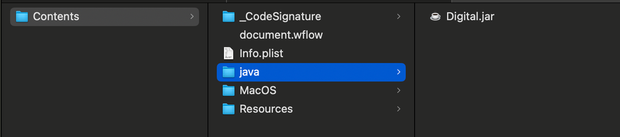

然后你就可以通过 launchpad `.app` 文件启动你的 java 项目了。

## 3 改图标

还是在 `Contents` 文件夹下，把这个 `.icns` 文件换成你自己的图标文件，比如可以把 `png` 文件[转换](https://www.aconvert.com/image/png-to-icns/)成 `icns` 文件，然后替换这个文件(文件名不变)。

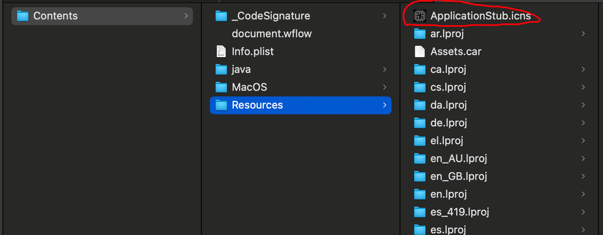

然后 Refresh the Icon Cache (if necessary):

```bash
touch /path/to/YOURJARFILE.app
killall Dock
```

Finish!

## 4 References

- [How to convert .jar to .app on Mac - a Java tutorial](https://www.youtube.com/watch?v=kwdK6Dg1a_Y)
- [Launching a jar file as an app on Mac (from the dock)](https://stackoverflow.com/questions/8916269/launching-a-jar-file-as-an-app-on-mac-from-the-dock)